**Deep Learning for Mechanical Engineering**  
**Generative Adversarial Networks (GAN)**

Instructor: Prof. Seungchul Lee  
http://iai.postech.ac.kr/  
Industrial AI Lab at POSTECH

# Problem 1

(1) The Turing test, developed by Alan Turing in 1950, is a test of a machine's ability to exhibit intelligent behaviour equivalent to, or indistinguishable from, that of a human. Turing proposed that a human evaluator would judge natural language conversations between a human and a machine designed to generate human-like responses. The evaluator would be aware that one of the two partners in conversation is a machine, and all participants would be separated from one another. The conversation would be limited to a text-only channel such as a computer keyboard and screen so the result would not depend on the machine's ability to render words as speech. If the evaluator cannot reliably tell the machine from the human, the machine is said to have passed the test. The test results do not depend on the machine's ability to give correct answers to questions, only how closely its answers resemble those a human would give.

(1-1) Describe GAN algorighm with the figure shown below.

(1-2) Write loss functions and optimizaton procedure.

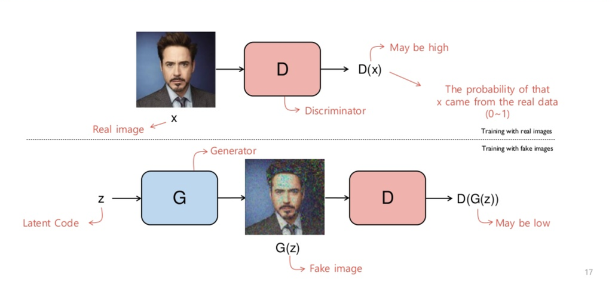

(2) You are training a GAN to generate nice human face images. The generator cost $J^{(G)}$ is extremly low, but the generator is not generating meaningful output images. What could be the reason? Describe it in relation to the loss function of the GAN.

# Problem 2

By the GAN algorithm, we can even change the style of images. In this problem, we will change the white-colored digit in a black background image to the black-colored digit in a white background image.

We will use the following GAN structure.

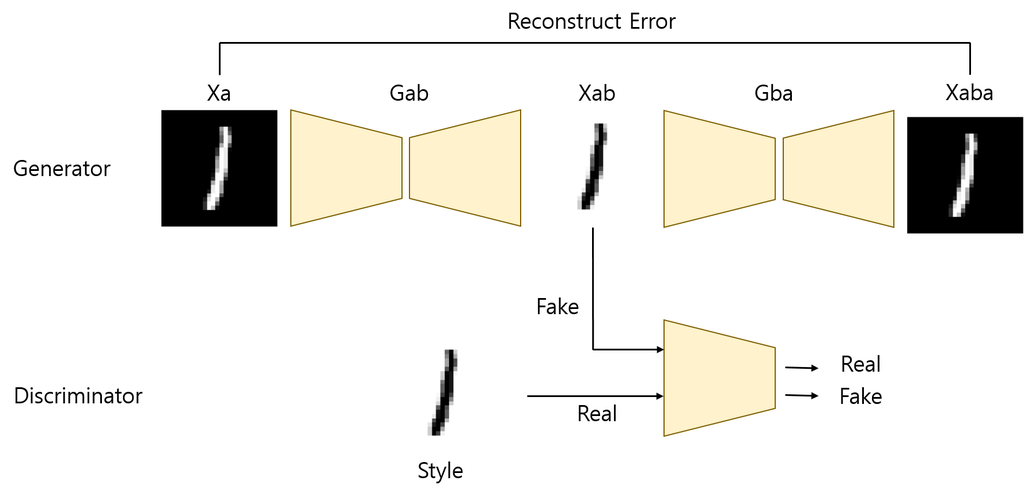

Download data from [here](https://www.dropbox.com/s/i6i2d12tzb7p2h1/one.npy?dl=1)

**Description**

- Domain A: white-colored number in a black background
- Domain B: black-colored number in a white background
- Generate Xab image by generator Gab
  - the structure of Gab is like an autoencoder
- Generate Xaba image by generator Gba
  - the structure of Gba is like an autoencoder
- Train the style to Gab generate styled image Xab
  - give reconstructed Xab image as a fake image and style image as a real image to the discriminator.

Note: I strongly recommend you to use either GPU or Colab. Don't use CPU to train your model! It will take a long time to complete training.

```python
import numpy as np
import matplotlib.pyplot as plt
#from six.moves import cPickle
import tensorflow as tf
```

(1) Load data. Then make colors of images inverted and plot one of them.

- one.npy
  - white-colored number in a black background image

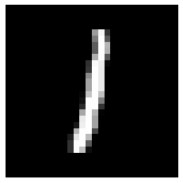

```python
# Your code here
#
```

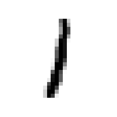

```python
# Your code here
#
```

(2) Define your model.

- Generator AB
  - `n_G_input`: 28 $\times$ 28
  - `n_G_encoder1`: 256
  - `n_G_latent1`: 50
  - `n_G_decoder1`: 256
- Generator BA
  - `n_G_encoder2`: 256
  - `n_G_latent2`: 50
  - `n_G_decoder2`: 256
- Discriminator
  - `n_D_input`: 28 $\times$ 28
  - `n_D_hidden`: 256
  - `n_D_output`: 2

```python
# Your code here
#
```

(3) Refer to the loss function below and train the model. And plot Xab image and Xaba image for each print.

Note that we are not asking you to make a perfect inverted image.

1: Fix $G$ and perform a gradient step to

$$\min_{D} E_{x \sim p_{\text{data}}(x)}\left[-\log D(x)\right] + E_{x \sim p_{z}(z)}\left[-\log (1-D(G(z)))\right]$$

2: Fix $D$ and perform a gradient step to

$$\min_{G} E_{x \sim p_{z}(z)}\left[-\log D(G(z))\right]$$

3: Minimize reconstruct error

$$\min \, (X_a-X_{aba})^2$$

```
Epoch: 0000 D_loss: 1.921 G_loss: 0.2217
```

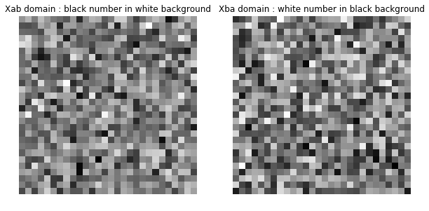

```
Epoch: 5000 D_loss: 0.006979 G_loss: 5.356
```

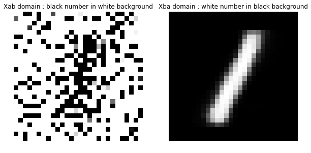

```
Epoch: 10000 D_loss: 0.001489 G_loss: 7.005
```

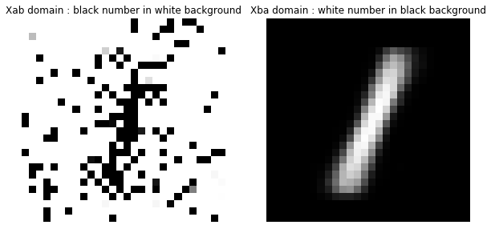

```
Epoch: 15000 D_loss: 0.02831 G_loss: 4.051
```

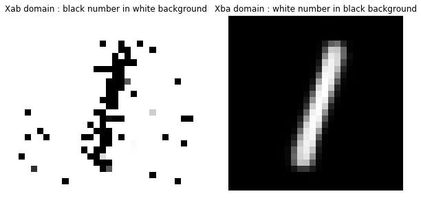

```
Epoch: 20000 D_loss: 0.005868 G_loss: 5.475
```

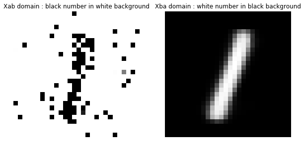

```
Epoch: 25000 D_loss: 0.001732 G_loss: 6.596
```

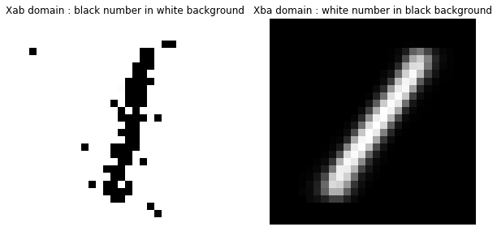

```python
# Your code here
#
```

# Problem 3: GAN for Data Imbalance Problem

Most industries seriously consider and control their yield rate of production. For this reason, a huge amount of cost is required to control the yield rate and many industries try to replace this yield inspection process to reduce cost. However, the acquisition data from the industry are mostly normal data and seldomly fault data. (generally about less than 5% of normal data)

In this case, even if the deep learning model is a biased model (i.e., it considers every data as normal class), the accuracy would be 95%. So, in this case, we can't believe the result from the deep learning model.

One way to solve this problem is the 'data generation' method. In this problem, we are going to solve the classification problem for imbalanced data by the GAN model.

Download data from [here](https://www.dropbox.com/s/nxwfny61cyvbxem/GAN_P3_datafiles.zip?dl=1).

- data format: npy
- the number of data: one-6000, seven-300

Note: strongly recommend you to use GPU rather than CPU. (you can use CoLab GPU for free)

(1) Load and preprocess data.

**Step 1**: load

- one.npy
- seven.npy

**Step 2**: convert the loaded data to a binary image

**Step 3**: split into train/test dataset

- `one` train index: 0~999
- `one` test index: 1000~6000
- `seven` train index: 0~4 (only five images)
- `seven` test index: 5~300

**Step 4**: labeling

- one-hot encoding

**Step 5**: batchmaker

- train and test batchmakers

```python
import numpy as np
import matplotlib.pyplot as plt
%matplotlib inline

import tensorflow as tf
from sklearn.model_selection import train_test_split
#from six.moves import cPickle
```

```python
# your code here
#
```

(2) Conduct the binary classification by convolution neural network (CNN) model.

**Structure**

- First convolution layer
  - filter size: $3\times 3$
  - channel: $32$
  - max pooling: $2\times 2$
- Second convolution layer
  - filter size: $3\times 3$
  - channel: $64$
  - max pooling: $2\times 2$
- Nonlinear activation: ReLu

**Model Training**

- Optimizer: AdamOptimizer
- Learning rate: $0.001$
- Epoch: $20$

**Model Test**

- radom image test
- `one` image test
- `seven` image test
- you should calculate the test accuracy

```python
# Build and train a model
#
```

```
<tensorflow.python.keras.callbacks.History at 0x1bbada6fc18>
```

```python
# test_dataset
#
```

[output not shown]

```python
# One image test
#
```

```python
# Seven image test
#
```

[output not shown]

**Generator**: deconvolution layer (= `conv2d_transpose`)

- Input layer: 100
- First deconvolution layer
  - filter size: $7\times 7$
  - channel: $64$
  - stride: $(1,1)$
  - padding: 'VALID'
- Second deconvolution layer:
  - filter size: $4\times 4$
  - channel: $32$
  - stride: $(2,2)$
  - padding: 'SAME'
- Third deconvolution layer
  - filter size: $4\times 4$
  - channel: $1$
  - stride: $(2,2)$
  - pading: 'SAME'

**Discriminator**: convolution layer

- Input layer: $28\times 28 \times 1$
- First convolution layer
  - filter size: $3\times 3$
  - channel: $32$
  - padding: 'SAME'
- Second convolution layer
  - filter size: $3\times 3$
  - channel: $64$
  - padding: 'SAME'
- no pooling layer

**Training**

- D_LR: 0.00004
- G_LR: 0.00008
- Max iteration: 5500
- Optimizer: AdamOptimizer

**Generated Images**

- Convert generated image to binary image
- original `one` images:original `seven` images + generated fake `seven` images = 1:1

```python
# Generator
#
```

```
Model: "sequential_1"
_________________________________________________________________
Layer (type)                 Output Shape              Param #
=================================================================
reshape (Reshape)            (None, 1, 1, 100)         0
_________________________________________________________________
conv2d_transpose (Conv2DTran (None, 7, 7, 64)          313664
_________________________________________________________________
conv2d_transpose_1 (Conv2DTr (None, 14, 14, 32)        32800
_________________________________________________________________
conv2d_transpose_2 (Conv2DTr (None, 28, 28, 1)         513
=================================================================
Total params: 346,977
Trainable params: 346,977
Non-trainable params: 0
_________________________________________________________________
```

```python
# Discriminator
#
```

```
Model: "sequential_2"
_________________________________________________________________
Layer (type)                 Output Shape              Param #
=================================================================
conv2d_2 (Conv2D)            (None, 28, 28, 32)        320
_________________________________________________________________
conv2d_3 (Conv2D)            (None, 28, 28, 64)        18496
_________________________________________________________________
flatten_1 (Flatten)          (None, 50176)             0
_________________________________________________________________
dense_2 (Dense)              (None, 100)               5017700
_________________________________________________________________
dense_3 (Dense)              (None, 1)                 101
=================================================================
Total params: 5,036,617
Trainable params: 5,036,617
Non-trainable params: 0
_________________________________________________________________
```

```python
# Combined model
#
```

```
Model: "model"
_________________________________________________________________
Layer (type)                 Output Shape              Param #
=================================================================
input_1 (InputLayer)         [(None, 100)]             0
_________________________________________________________________
sequential_1 (Sequential)    (None, 28, 28, 1)         346977
_________________________________________________________________
sequential_2 (Sequential)    (None, 1)                 5036617
=================================================================
Total params: 5,383,594
Trainable params: 346,977
Non-trainable params: 5,036,617
_________________________________________________________________
```

```python
# Your code here
#
```

Step 1: Fix $G$ and perform a gradient step to

$$\min_{D} E_{x \sim p_{\text{data}}(x)}\left[-\log D(x)\right] + E_{x \sim p_{z}(z)}\left[-\log (1-D(G(z)))\right]$$

Step 2: Fix $D$ and perform a gradient step to

$$\min_{G} E_{x \sim p_{z}(z)}\left[-\log D(G(z))\right]$$

```
Iteration:  0
Discriminator Loss:  1.462611973285675
Generator Loss:  0.7039922475814819
```

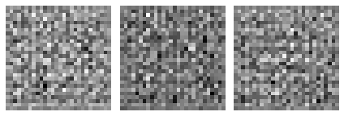

```
Iteration:  500
Discriminator Loss:  0.00023682334722252563
Generator Loss:  8.83740520477295
```

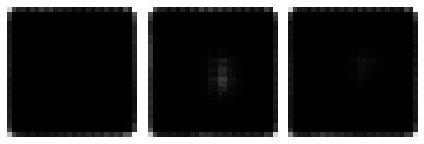

```
Iteration:  1000
Discriminator Loss:  0.00015678536874474958
Generator Loss:  13.393343925476074
```

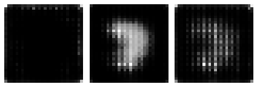

```
Iteration:  1500
Discriminator Loss:  9.161571506410837e-05
Generator Loss:  15.968523025512695
```

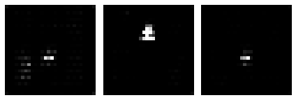

```
Iteration:  2000
Discriminator Loss:  0.00016329843856510706
Generator Loss:  10.955981254577637
```

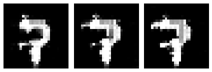

```
Iteration:  2500
Discriminator Loss:  0.0005903868295717984
Generator Loss:  11.144515037536621
```

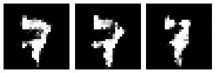

```
Iteration:  3000
Discriminator Loss:  0.026750773191452026
Generator Loss:  8.245807647705078
```

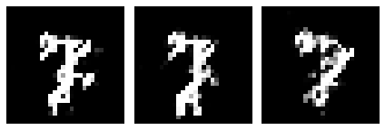

```
Iteration:  3500
Discriminator Loss:  0.019372152164578438
Generator Loss:  8.17862319946289
```

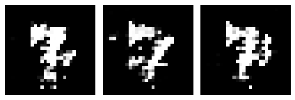

```
Iteration:  4000
Discriminator Loss:  0.012854257598519325
Generator Loss:  6.926724433898926
```

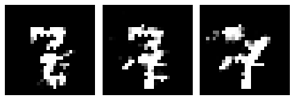

```
Iteration:  4500
Discriminator Loss:  0.004120861878618598
Generator Loss:  8.119384765625
```

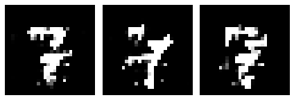

```
Iteration:  5000
Discriminator Loss:  0.005851384485140443
Generator Loss:  9.12647819519043
```

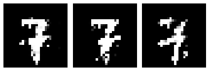

```python
# Your code here
#
```

```python
# save generated data
# N = len(one) - len(seven)
#
```

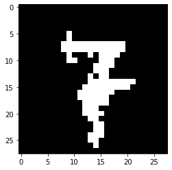

```python
# Randomly plot one generated image among N
#
```

(4) Train the CNN model again using the original and generated (or augmented) data.

- stack the generated data and original train data of `seven`
- define new train data by putting new `seven` train and `one` train data altogether
- define new train label
- use the same CNN structure
- test
  - random image test
  - one image test
  - seven image test

```python
# stack the generated data and original train data of seven
# define new train data by putting new seven train and one train data altogether
#
```

```
new_train_data:  (2000, 28, 28, 1)
```

```python
# Your code here
#
```

```
<tensorflow.python.keras.callbacks.History at 0x1bbb5327b00>
```

```python
# test_dataset
#
```

```python
# one image test
#
```

```python
# seven image test
#
```